# Time Series Forecasting: Daily Covid Cases in the US

## Data Description

The given data consists of daily new Covid cases in United States from January 2020 to January 2022. The data has been sourced from https://ourworldindata.org/covid-cases. The number of new COVID-19 cases in the country continues to report soaring rates of new infections due to the rapid spread of the highly transmissible omicron variant. This projects aims to forecast the number of new cases going ahead in 2022 and also try to determine when will this new wave due to the omicron variant come to an end. The reason for choosing this dataset is that Covid is something that has become a part of everone's life and people have questions regarding how long this pandemic is going to last. The variations in the data is due to the multiplicative factor by which the virus continues to spread. This can lead to an exponential pattern in which the virus is spreading and can be forecasted well using time series forecasting methods.

## Data Importing and Preprocessing

```python
#importing libraries
import warnings
import pandas as pd
import numpy as np
import matplotlib.pyplot as plt
import seaborn as sns
warnings.filterwarnings("ignore")
```

```python
df = pd.read_csv('/Users/rajesh/documents/Assignments/Time Series/Project/US Daily Covid Cases copy.csv')
```

```python
df.head()
```

|  | location | date | new_cases |
| --- | --- | --- | --- |
| 0 | United States | 1/22/20 | NaN |
| 1 | United States | 1/23/20 | 0.0 |
| 2 | United States | 1/24/20 | 1.0 |
| 3 | United States | 1/25/20 | 0.0 |
| 4 | United States | 1/26/20 | 3.0 |

```python
# Replacing new cases for the first day
df['new_cases'][0] = 1
df.head()
```

|  | location | date | new_cases |
| --- | --- | --- | --- |
| 0 | United States | 1/22/20 | 1.0 |
| 1 | United States | 1/23/20 | 0.0 |
| 2 | United States | 1/24/20 | 1.0 |
| 3 | United States | 1/25/20 | 0.0 |
| 4 | United States | 1/26/20 | 3.0 |

```python
#Checking for null values in the data
df.isnull().sum()
```

```
location     0
date         0
new_cases    0
dtype: int64
```

The data is clean and has no null values. Since the data is only for United States, we can drop the location column.

```python
#dropping location
df = df.drop('location',axis=1)
```

```python
#Checking for data type of each column
df.info()
```

```
<class 'pandas.core.frame.DataFrame'>
RangeIndex: 729 entries, 0 to 728
Data columns (total 2 columns):
date         729 non-null object
new_cases    729 non-null float64
dtypes: float64(1), object(1)
memory usage: 11.5+ KB
```

We would need to change the data type of date and new cases.

```python
#changing data types
df['date']= pd.to_datetime(df['date'])
df['new_cases']=df['new_cases'].astype('int')
```

```python
print('Time period start: {}\nTime period end: {}'.format(df.date.min(),df.date.max()))
```

```
Time period start: 2020-01-22 00:00:00
Time period end: 2022-01-19 00:00:00
```

```python
df.shape
```

```
(729, 2)
```

```python
#Checking for some basic statistics
df.describe()
```

|  | new_cases |
| --- | --- |
| count | 7.290000e+02 |
| mean | 9.418834e+04 |
| std | 1.376103e+05 |
| min | 0.000000e+00 |
| 25% | 2.714900e+04 |
| 50% | 5.418900e+04 |
| 75% | 1.154190e+05 |
| max | 1.369226e+06 |

```python
#Setting date column as index of the dataframe
df = df.set_index('date')
```

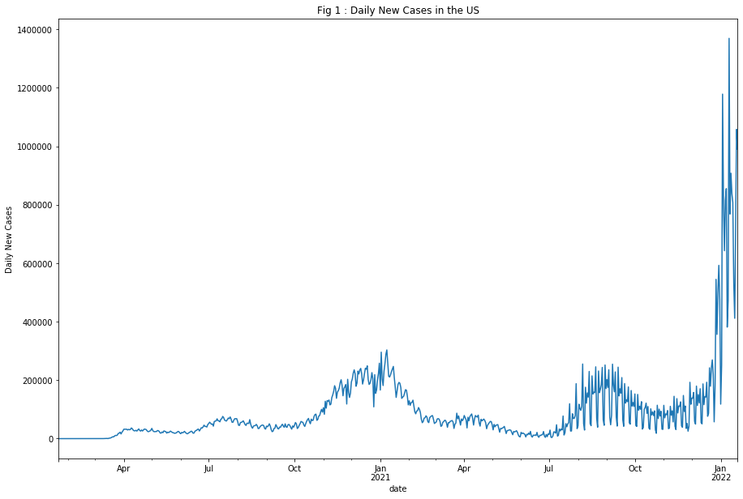

```python
plt.figure(figsize=(15,10))
plt.xlabel('Date')
plt.ylabel('Daily New Cases')
plt.title('Fig 1 : Daily New Cases in the US')
df['new_cases'].plot()
plt.show()
```

We can see that the daily new cases started to increase gradually through 2020 and then went up exponentially around early part of 2021. We saw a third wave of the virus in the third quarter of 2021. Due to the outbreak of the Omicron variant, we saw a big spike in terms of the number of new cases in early 2022.

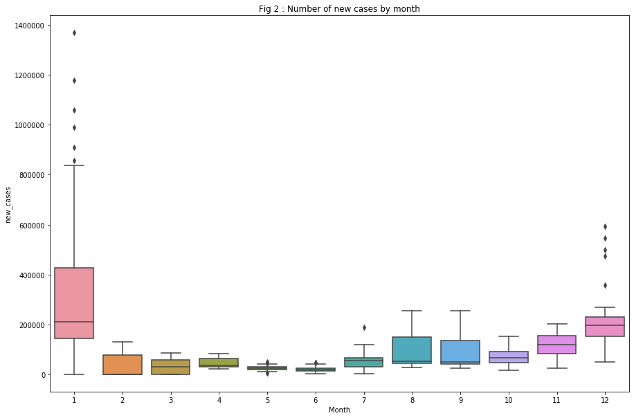

```python
plt.figure(figsize=(15,10))
sns.boxplot(df.index.month, df['new_cases'])
plt.xlabel('Month')
plt.title('Fig 2 : Number of new cases by month')
plt.show()
```

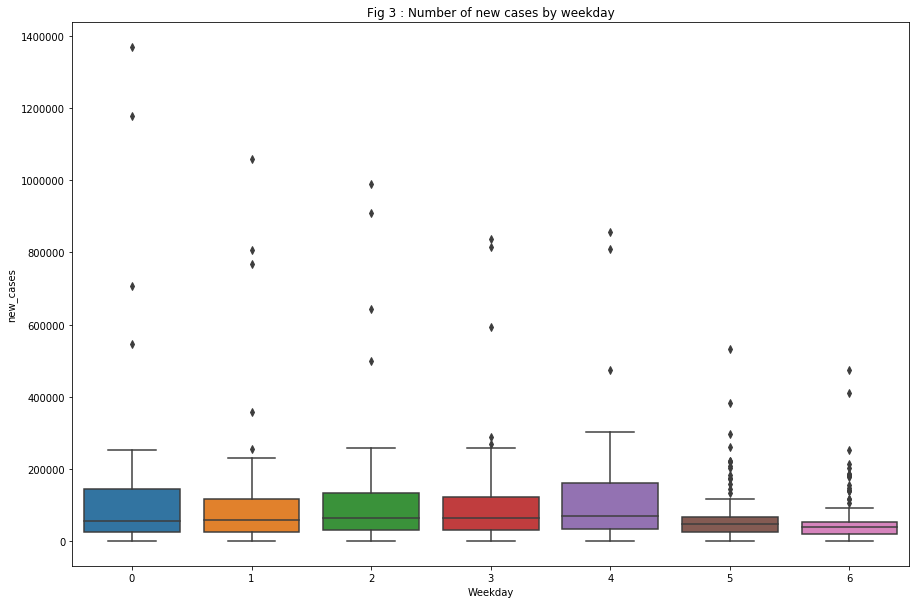

```python
plt.figure(figsize=(15,10))
sns.boxplot(df.index.weekday, df['new_cases'])
plt.xlabel('Weekday')
plt.title('Fig 3 : Number of new cases by weekday')
plt.show()
```

Here 0 stands for Monday and 6 represents Sunday. We can observe a weekly seasonality in this time series with Saturdays and Sundays having comparatively lesser new cases as compared to weekdays.

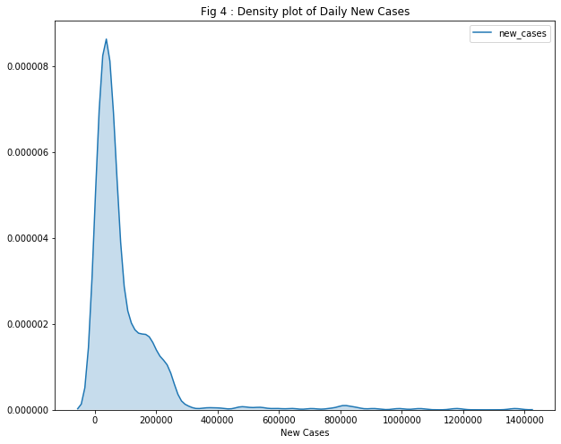

```python
plt.figure(figsize=(10,8))
sns.kdeplot(df['new_cases'],shade=True)
plt.title('Fig 4 : Density plot of Daily New Cases')
plt.xlabel('New Cases')
plt.show()
```

The density plot above shows the distribution of the number of cases. We can see that the major frequency lies in the region less than 200k

## ARIMA Modeling

In order to fit an ARIMA model, we need to make the time series mean and variance stationary. Looking at figure 1 above, we can conclude that the series is not variance stationary. We will run some tests later on to test the mean stationarity.

### Making the series variance stationary by applying a log transformation

```python
#applying log transformation
ln_df = np.log(df)
```

```python
ln_df.head()
```

| date | new_cases |
| --- | --- |
| 2020-01-22 | 0.000000 |
| 2020-01-23 | -inf |
| 2020-01-24 | 0.000000 |
| 2020-01-25 | -inf |
| 2020-01-26 | 1.098612 |

Here, we are observing infinity as log transformation of 0. Since January and February 2020 were early days for the virus to spread, we can replace 0s with 1 for these 2 months and reapply a log transformation.

```python
df[df['new_cases']==0]=1
df.head()
```

| date | new_cases |
| --- | --- |
| 2020-01-22 | 1 |
| 2020-01-23 | 1 |
| 2020-01-24 | 1 |
| 2020-01-25 | 1 |
| 2020-01-26 | 3 |

```python
#reapplying log transformation
ln_df = np.log(df)
ln_df.head()
```

| date | new_cases |
| --- | --- |
| 2020-01-22 | 0.000000 |
| 2020-01-23 | 0.000000 |
| 2020-01-24 | 0.000000 |
| 2020-01-25 | 0.000000 |
| 2020-01-26 | 1.098612 |

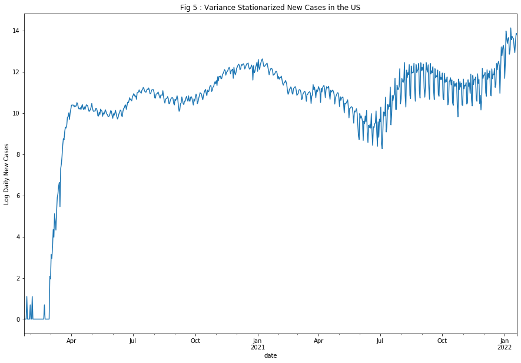

```python
plt.figure(figsize=(15,10))
plt.xlabel('Date')
plt.ylabel('Log Daily New Cases')
plt.title('Fig 5 : Variance Stationarized New Cases in the US')
ln_df['new_cases'].plot()
plt.show()
```

We can observe that the time series is now variance stationary. However, we need to check whether it is mean stationary.

### Checking for mean stationarity

```python
# Augmented Dickey Fuller test
from statsmodels.tsa.stattools import adfuller
adfuller(ln_df)
```

```
(-5.34306243146504,
 4.456202356993862e-06,
 20,
 708,
 {'1%': -3.439620010600208,
  '5%': -2.8656309041017756,
  '10%': -2.5689484851894413},
 107.76017678870903)
```

The p value obtained is 4.45e-06 , which is lower than 0.05. This indicates that the data is mean stationary.

```python
# KPSS test
from statsmodels.tsa.stattools import kpss
kpss(ln_df)
```

```
(1.16737249717947,
 0.01,
 20,
 {'10%': 0.347, '5%': 0.463, '2.5%': 0.574, '1%': 0.739})
```

The p value obtained is 0.01 (less than 0.05), which indicates that the data is mean non stationary

### Calculating first difference to make the series mean stationary

```python
df_diff = pd.DataFrame(ln_df['new_cases'] - ln_df['new_cases'].shift(1))
df_diff.head()
```

| date | new_cases |
| --- | --- |
| 2020-01-22 | NaN |
| 2020-01-23 | 0.000000 |
| 2020-01-24 | 0.000000 |
| 2020-01-25 | 0.000000 |
| 2020-01-26 | 1.098612 |

```python
#removing missing value
df_diff = df_diff.dropna()
df_diff.head()
```

| date | new_cases |
| --- | --- |
| 2020-01-23 | 0.000000 |
| 2020-01-24 | 0.000000 |
| 2020-01-25 | 0.000000 |
| 2020-01-26 | 1.098612 |
| 2020-01-27 | -1.098612 |

```python
# Augmented Dickey Fuller test
from statsmodels.tsa.stattools import adfuller
adfuller(df_diff)
```

```
(-3.4188141535940764,
 0.010333976815479802,
 20,
 707,
 {'1%': -3.439633170421852,
  '5%': -2.8656367026715337,
  '10%': -2.5689515744354794},
 116.60002961028977)
```

The p-value of the ADF test now comes out to be 0.01, which indicates mean stationary data.

```python
# KPSS test
from statsmodels.tsa.stattools import kpss
kpss(df_diff)
```

```
(0.37670827502580145,
 0.08719470904060282,
 20,
 {'10%': 0.347, '5%': 0.463, '2.5%': 0.574, '1%': 0.739})
```

The p-value of the KPSS test now comes out to be greater than 0.05, which indicates mean stationary data.

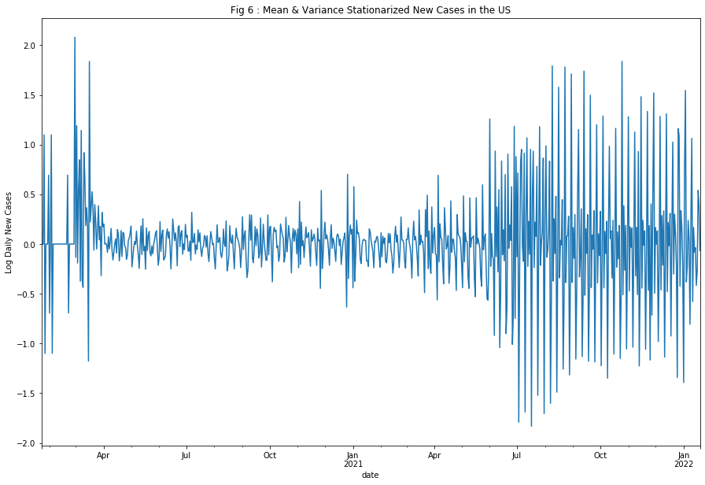

```python
plt.figure(figsize=(15,10))
plt.xlabel('Date')
plt.ylabel('Log Daily New Cases')
plt.title('Fig 6 : Mean & Variance Stationarized New Cases in the US')
df_diff['new_cases'].plot()
plt.show()
```

### Plotting ACF and PACF

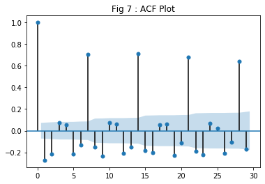

```python
#plotting acf
from statsmodels.graphics.tsaplots import plot_acf
plot_acf(df_diff)
plt.title('Fig 7 : ACF Plot')
plt.show()
```

The ACF shows high correlation as well as dampening effect at every 7th lag, which indicates a weekly seasonality. Since we can see 3 time series elements show correlation more than the significance level, it looks like a MA 3 process.

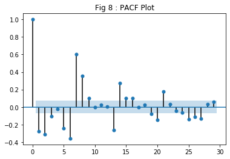

```python
from statsmodels.graphics.tsaplots import plot_pacf
plot_pacf(df_diff)
plt.title('Fig 8 : PACF Plot')
plt.show()
```

Since we can see 2 time series elements show correlation more than the significance level, it looks like a AR 2 process.

### Plotting ARIMA Models

```python
# Model 1 (2,1,3)
from statsmodels.tsa.arima_model import ARIMA
model1 = ARIMA(ln_df['new_cases'], order=(3,1,2))
model1_fit = model1.fit(disp=1)
print(model1_fit.summary())
```

```
                             ARIMA Model Results
==============================================================================
Dep. Variable:            D.new_cases   No. Observations:                  728
Model:                 ARIMA(3, 1, 2)   Log Likelihood                -339.489
Method:                       css-mle   S.D. of innovations                nan
Date:                Sat, 26 Feb 2022   AIC                            692.978
Time:                        14:21:57   BIC                            725.110
Sample:                    01-23-2020   HQIC                           705.376
                         - 01-19-2022
=====================================================================================
                        coef    std err          z      P>|z|      [0.025      0.975]
-------------------------------------------------------------------------------------
const                 0.0193        nan        nan        nan         nan         nan
ar.L1.D.new_cases    -0.7731        nan        nan        nan         nan         nan
ar.L2.D.new_cases    -1.1449        nan        nan        nan         nan         nan
ar.L3.D.new_cases    -0.3191   1.52e-06   -2.1e+05      0.000      -0.319      -0.319
ma.L1.D.new_cases     0.4649      0.014     33.697      0.000       0.438       0.492
ma.L2.D.new_cases     0.9508      0.010     95.263      0.000       0.931       0.970
                                    Roots
=============================================================================
                  Real          Imaginary           Modulus         Frequency
-----------------------------------------------------------------------------
AR.1           -0.2270           -0.9739j            1.0000           -0.2864
AR.2           -0.2270           +0.9739j            1.0000            0.2864
AR.3           -3.1334           -0.0000j            3.1334           -0.5000
MA.1           -0.2445           -0.9960j            1.0256           -0.2883
MA.2           -0.2445           +0.9960j            1.0256            0.2883
-----------------------------------------------------------------------------
```

```python
# Model 2 (2,2,3)
model2 = ARIMA(ln_df['new_cases'], order=(2,1,0))
model2_fit = model2.fit()
print(model2_fit.summary())
```

```
                             ARIMA Model Results
==============================================================================
Dep. Variable:            D.new_cases   No. Observations:                  728
Model:                 ARIMA(2, 1, 0)   Log Likelihood                -434.841
Method:                       css-mle   S.D. of innovations              0.440
Date:                Sat, 26 Feb 2022   AIC                            877.682
Time:                        14:21:58   BIC                            896.043
Sample:                    01-23-2020   HQIC                           884.767
                         - 01-19-2022
=====================================================================================
                        coef    std err          z      P>|z|      [0.025      0.975]
-------------------------------------------------------------------------------------
const                 0.0189      0.010      1.939      0.053      -0.000       0.038
ar.L1.D.new_cases    -0.3580      0.035    -10.176      0.000      -0.427      -0.289
ar.L2.D.new_cases    -0.3123      0.035     -8.883      0.000      -0.381      -0.243
                                    Roots
=============================================================================
                  Real          Imaginary           Modulus         Frequency
-----------------------------------------------------------------------------
AR.1           -0.5733           -1.6952j            1.7895           -0.3019
AR.2           -0.5733           +1.6952j            1.7895            0.3019
-----------------------------------------------------------------------------
```

```python
# Model 3 (4,1,3)
model3 = ARIMA(ln_df['new_cases'], order=(4,1,3))
model3_fit = model3.fit()
print(model3_fit.summary())
```

```
                             ARIMA Model Results
==============================================================================
Dep. Variable:            D.new_cases   No. Observations:                  728
Model:                 ARIMA(4, 1, 3)   Log Likelihood                -329.439
Method:                       css-mle   S.D. of innovations              0.379
Date:                Sat, 26 Feb 2022   AIC                            676.879
Time:                        14:22:01   BIC                            718.191
Sample:                    01-23-2020   HQIC                           692.820
                         - 01-19-2022
=====================================================================================
                        coef    std err          z      P>|z|      [0.025      0.975]
-------------------------------------------------------------------------------------
const                 0.0210      0.015      1.400      0.162      -0.008       0.050
ar.L1.D.new_cases     0.1965      0.052      3.806      0.000       0.095       0.298
ar.L2.D.new_cases    -0.3810      0.031    -12.219      0.000      -0.442      -0.320
ar.L3.D.new_cases     0.7936      0.042     19.057      0.000       0.712       0.875
ar.L4.D.new_cases     0.3203      0.039      8.135      0.000       0.243       0.397
ma.L1.D.new_cases    -0.5030      0.041    -12.408      0.000      -0.582      -0.424
ma.L2.D.new_cases     0.4946      0.026     19.191      0.000       0.444       0.545
ma.L3.D.new_cases    -0.9170      0.034    -26.664      0.000      -0.984      -0.850
                                    Roots
=============================================================================
                  Real          Imaginary           Modulus         Frequency
-----------------------------------------------------------------------------
AR.1            1.0222           -0.0000j            1.0222           -0.0000
AR.2           -0.2274           -0.9754j            1.0015           -0.2865
AR.3           -0.2274           +0.9754j            1.0015            0.2865
AR.4           -3.0454           -0.0000j            3.0454           -0.5000
MA.1            1.0319           -0.0000j            1.0319           -0.0000
MA.2           -0.2463           -0.9981j            1.0280           -0.2885
MA.3           -0.2463           +0.9981j            1.0280            0.2885
-----------------------------------------------------------------------------
```

```python
# Model 4 (3,2,2)
model4 = ARIMA(ln_df['new_cases'], order=(3,2,2))
model4_fit = model4.fit()
print(model4_fit.summary())
```

```
                             ARIMA Model Results
==============================================================================
Dep. Variable:           D2.new_cases   No. Observations:                  727
Model:                 ARIMA(3, 2, 2)   Log Likelihood                -398.385
Method:                       css-mle   S.D. of innovations              0.417
Date:                Sat, 26 Feb 2022   AIC                            810.770
Time:                        14:22:04   BIC                            842.893
Sample:                    01-24-2020   HQIC                           823.166
                         - 01-19-2022
======================================================================================
                         coef    std err          z      P>|z|      [0.025      0.975]
--------------------------------------------------------------------------------------
const              -6.037e-05      0.001     -0.072      0.943      -0.002       0.002
ar.L1.D2.new_cases     0.2775      0.052      5.317      0.000       0.175       0.380
ar.L2.D2.new_cases    -0.1590      0.042     -3.789      0.000      -0.241      -0.077
ar.L3.D2.new_cases     0.0030      0.045      0.067      0.947      -0.086       0.092
ma.L1.D2.new_cases    -1.7698      0.037    -48.104      0.000      -1.842      -1.698
ma.L2.D2.new_cases     0.8175      0.035     23.389      0.000       0.749       0.886
                                    Roots
=============================================================================
                  Real          Imaginary           Modulus         Frequency
-----------------------------------------------------------------------------
AR.1            0.8378           -2.4070j            2.5486           -0.1967
AR.2            0.8378           +2.4070j            2.5486            0.1967
AR.3           51.0623           -0.0000j           51.0623           -0.0000
MA.1            1.0825           -0.2269j            1.1060           -0.0329
MA.2            1.0825           +0.2269j            1.1060            0.0329
-----------------------------------------------------------------------------
```

Based on the 4 ARIMA models fit, Model 3 ARIMA (4,1,3) is the best model according to AIC and BIC both

### Fitting an Auto ARIMA Model

```python
from pmdarima.arima import auto_arima
model = auto_arima(ln_df['new_cases'], trace=True, error_action='ignore', suppress_warnings=True)
model.fit(ln_df['new_cases'])
```

```
Performing stepwise search to minimize aic
 ARIMA(2,2,2)(0,0,0)[0]             : AIC=inf, Time=0.57 sec
 ARIMA(0,2,0)(0,0,0)[0]             : AIC=1681.933, Time=0.03 sec
 ARIMA(1,2,0)(0,0,0)[0]             : AIC=1452.089, Time=0.05 sec
 ARIMA(0,2,1)(0,0,0)[0]             : AIC=inf, Time=0.46 sec
 ARIMA(2,2,0)(0,0,0)[0]             : AIC=1243.669, Time=0.08 sec
 ARIMA(3,2,0)(0,0,0)[0]             : AIC=1125.906, Time=0.12 sec
 ARIMA(4,2,0)(0,0,0)[0]             : AIC=1116.353, Time=0.16 sec
 ARIMA(5,2,0)(0,0,0)[0]             : AIC=1112.762, Time=0.16 sec
 ARIMA(5,2,1)(0,0,0)[0]             : AIC=798.538, Time=0.44 sec
 ARIMA(4,2,1)(0,0,0)[0]             : AIC=873.294, Time=0.42 sec
 ARIMA(5,2,2)(0,0,0)[0]             : AIC=656.857, Time=1.08 sec
 ARIMA(4,2,2)(0,0,0)[0]             : AIC=861.405, Time=0.83 sec
 ARIMA(5,2,3)(0,0,0)[0]             : AIC=inf, Time=1.96 sec
 ARIMA(4,2,3)(0,0,0)[0]             : AIC=inf, Time=1.35 sec
 ARIMA(5,2,2)(0,0,0)[0] intercept   : AIC=665.975, Time=2.23 sec

Best model:  ARIMA(5,2,2)(0,0,0)[0]
Total fit time: 9.963 seconds
```

```
ARIMA(order=(5, 2, 2), scoring_args={}, suppress_warnings=True,
      with_intercept=False)
```

Auto ARIMA suggests order of (5,2,2) as the best model.

```python
# fitting the best model (5,2,2)
model5 = ARIMA(ln_df['new_cases'], order=(5,2,2))
model5_fit = model5.fit()
print(model5_fit.summary())
```

```
                             ARIMA Model Results
==============================================================================
Dep. Variable:           D2.new_cases   No. Observations:                  727
Model:                 ARIMA(5, 2, 2)   Log Likelihood                -320.428
Method:                       css-mle   S.D. of innovations              0.375
Date:                Sat, 26 Feb 2022   AIC                            658.857
Time:                        14:22:19   BIC                            700.157
Sample:                    01-24-2020   HQIC                           674.794
                         - 01-19-2022
======================================================================================
                         coef    std err          z      P>|z|      [0.025      0.975]
--------------------------------------------------------------------------------------
const               1.278e-05      0.002      0.007      0.994      -0.004       0.004
ar.L1.D2.new_cases    -0.1445      0.034     -4.283      0.000      -0.211      -0.078
ar.L2.D2.new_cases    -0.5122      0.037    -13.661      0.000      -0.586      -0.439
ar.L3.D2.new_cases    -0.4180      0.042     -9.986      0.000      -0.500      -0.336
ar.L4.D2.new_cases    -0.3911      0.037    -10.625      0.000      -0.463      -0.319
ar.L5.D2.new_cases    -0.5876      0.048    -12.277      0.000      -0.681      -0.494
ma.L1.D2.new_cases    -1.2877      0.049    -26.234      0.000      -1.384      -1.191
ma.L2.D2.new_cases     0.6870      0.061     11.283      0.000       0.568       0.806
                                    Roots
=============================================================================
                  Real          Imaginary           Modulus         Frequency
-----------------------------------------------------------------------------
AR.1            0.6457           -0.8039j            1.0311           -0.1423
AR.2            0.6457           +0.8039j            1.0311            0.1423
AR.3           -0.3571           -1.0772j            1.1349           -0.3009
AR.4           -0.3571           +1.0772j            1.1349            0.3009
AR.5           -1.2427           -0.0000j            1.2427           -0.5000
MA.1            0.9371           -0.7598j            1.2065           -0.1084
MA.2            0.9371           +0.7598j            1.2065            0.1084
-----------------------------------------------------------------------------
```

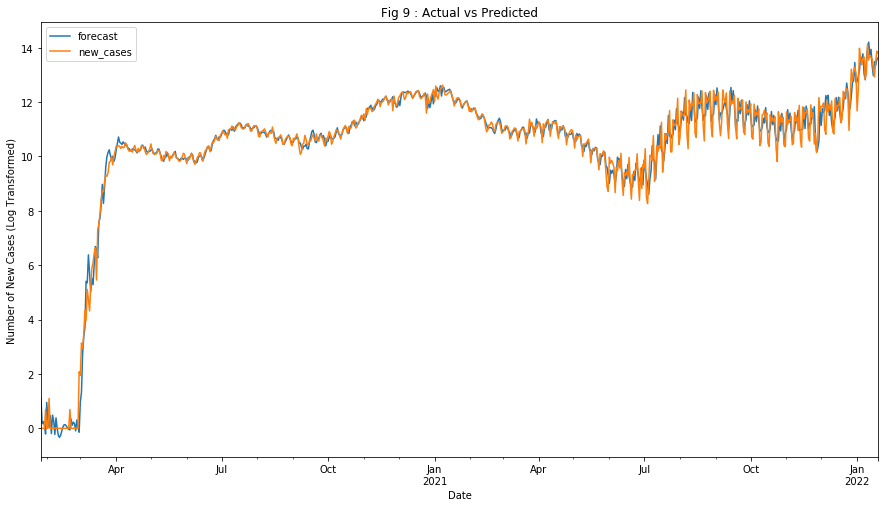

```python
# Plotting the predicted and actual values using best model
fig, ax = plt.subplots(figsize = (15,8))
ax.set_xlabel('Date')
ax.set_ylabel('Number of New Cases (Log Transformed)')
model5_fit.plot_predict(5, ax = ax)
plt.title('Fig 9 : Actual vs Predicted')
plt.show()
```

The plot shows that the predicted and original data seem close to each other. The model looks like a good fit.

### Residual Analysis

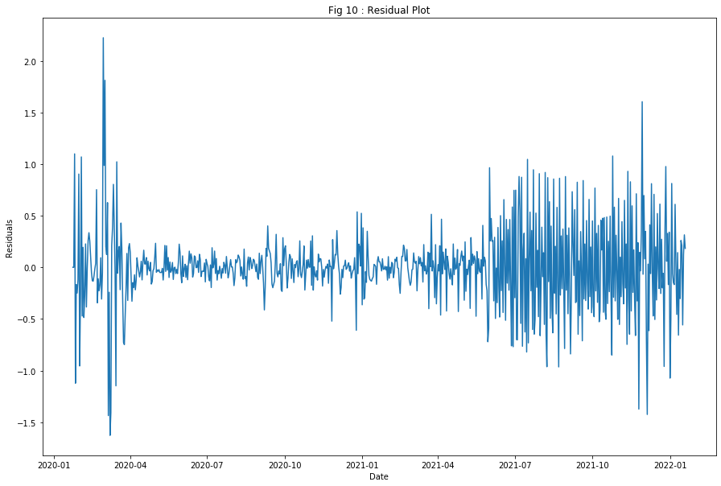

```python
plt.figure(figsize=(15,10))
plt.xlabel('Date')
plt.ylabel('Residuals')
plt.title('Fig 10 : Residual Plot')
residuals = pd.DataFrame(model5_fit.resid)
plt.plot(residuals)
plt.show()
```

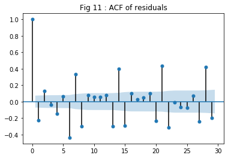

```python
#examining acf of residuals
plot_acf(residuals)
plt.title('Fig 11 : ACF of residuals')
plt.show()
```

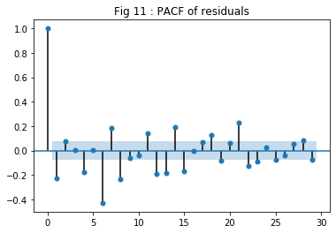

```python
#examining pacf of residuals
plot_pacf(residuals)
plt.title('Fig 11 : PACF of residuals')
plt.show()
```

```python
# applying Box Ljung Test
import statsmodels.api as sm
ljung = sm.stats.acorr_ljungbox(residuals, lags= 5)
p_value = ljung[1][-1]
print('p value obtained is ',p_value)
```

```
p value obtained is  46.7862928979956
```

### Evaluating in sample performance through RMSE

```python
# getting predictions and taking inverse of log to get back to original scale
predictions = pd.DataFrame(model5_fit.predict())
predictions.columns = ['Prediction']
predictions['Prediction'] = np.exp(predictions['Prediction'])
```

```python
from sklearn.metrics import mean_squared_error
from math import sqrt
mse = mean_squared_error(df['new_cases'][2:], predictions)
rmse = sqrt(mse)
print('RMSE: %f' % rmse)
```

```
RMSE: 166907.888687
```

```python
# generating foreacasts for the next 30 days
n=30
forecast,err,ci = model5_fit.forecast(steps=n)
df_forecast = pd.DataFrame({'forecast':forecast},index=pd.date_range(start='2022/01/20', periods=n))
```

```python
#taking inverse of log to get back to original scale
df_forecast['forecast'] = np.exp(df_forecast['forecast'])
df_forecast.head()
```

|  | forecast |
| --- | --- |
| 2022-01-20 | 877998.672752 |
| 2022-01-21 | 799331.962077 |
| 2022-01-22 | 598484.959623 |
| 2022-01-23 | 605601.082878 |
| 2022-01-24 | 863439.087057 |

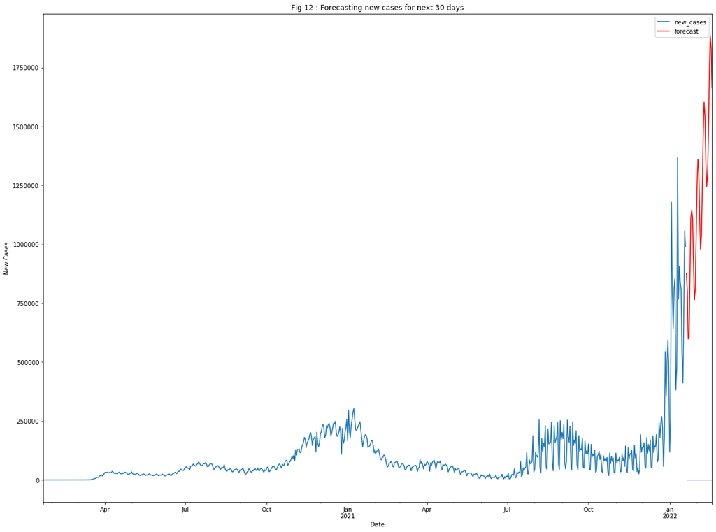

```python
ax = df.plot(label='observed', figsize=(20, 15))
df_forecast.plot(ax=ax,label='Forecast',color='r')
ax.fill_between(df_forecast.index,
                ci[:,0],
                ci[:,1], color='b', alpha=.25)
ax.set_xlabel('Date')
ax.set_ylabel('New Cases')
plt.title('Fig 12 : Forecasting new cases for next 30 days')
plt.legend()
plt.show()
```

## Facebook Prophet Model

```python
# initializing Prophet Model
from fbprophet import Prophet
model = Prophet()
```

```python
#creating a new dataframe and renaming the columns of the dataframe
dfb = df.reset_index()
dfb.columns=['ds','y']
model.fit(dfb)
```

```
INFO:fbprophet:Disabling yearly seasonality. Run prophet with yearly_seasonality=True to override this.
INFO:fbprophet:Disabling daily seasonality. Run prophet with daily_seasonality=True to override this.
```

```
<fbprophet.forecaster.Prophet at 0x7fe1050a9bd0>
```

```python
# Create Future dates
future = model.make_future_dataframe(periods=365)

# Predict Prices
forecast = model.predict(future)
forecast[['ds', 'yhat', 'yhat_lower', 'yhat_upper']].tail()
```

|  | ds | yhat | yhat_lower | yhat_upper |
| --- | --- | --- | --- | --- |
| 1089 | 2023-01-15 | 1.079254e+06 | 847233.306561 | 1.312573e+06 |
| 1090 | 2023-01-16 | 1.132894e+06 | 898244.298272 | 1.376539e+06 |
| 1091 | 2023-01-17 | 1.122303e+06 | 901571.893844 | 1.358446e+06 |
| 1092 | 2023-01-18 | 1.130923e+06 | 898953.039258 | 1.384203e+06 |
| 1093 | 2023-01-19 | 1.128271e+06 | 919184.028501 | 1.368989e+06 |

The model successfully forecasted the number of new cases for the next 365 days. We can see the forecasted values of the time series for the last 5 days of the forecasted period along with their upper and lower bound.

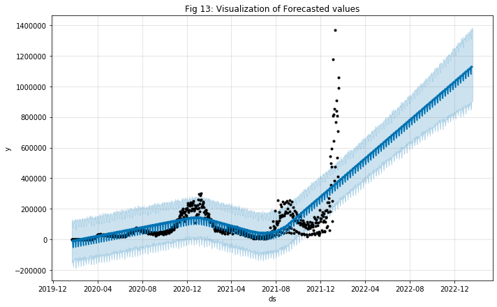

```python
#visualizing the forecasted values
import matplotlib.pyplot as plt
model.plot(forecast)
plt.title('Fig 13: Visualization of Forecasted values')
plt.show()
```

The model should not take into account a saturating minimum or maximum point since all the values forecasted by the model are reasonable enough.

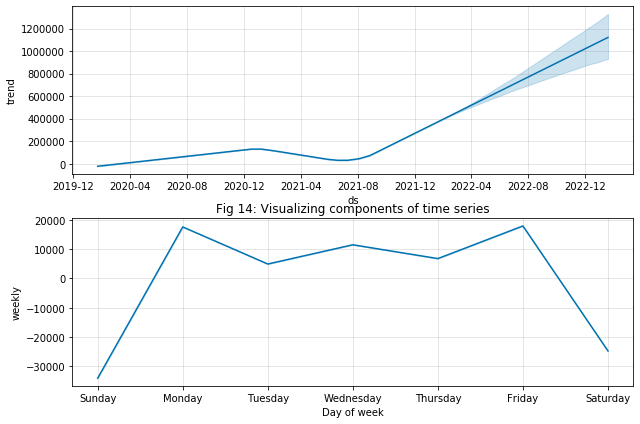

```python
# visualizing components of the time series
model.plot_components(forecast)
plt.title('Fig 14: Visualizing components of time series')
plt.show()
```

It is quite evident that COVID 19 daily cases follow a weekly seasonality. As we can see in the above chart, there are less number of new cases on weekends as compared to weekdays.

```python
# calculating in sample RMSE
yhat = forecast[:-365]['yhat']
y = dfb['y']
RMSE = np.sqrt((np.power((yhat - y),2)).mean())
RMSE
```

```
101675.54395801513
```

### Changepoint Analysis

```python
#listing the potential changepoints
model.changepoints
```

```
23    2020-02-14
47    2020-03-09
70    2020-04-01
93    2020-04-24
116   2020-05-17
140   2020-06-10
163   2020-07-03
186   2020-07-26
210   2020-08-19
233   2020-09-11
256   2020-10-04
279   2020-10-27
303   2020-11-20
326   2020-12-13
349   2021-01-05
372   2021-01-28
396   2021-02-21
419   2021-03-16
442   2021-04-08
466   2021-05-02
489   2021-05-25
512   2021-06-17
535   2021-07-10
559   2021-08-03
582   2021-08-26
Name: ds, dtype: datetime64[ns]
```

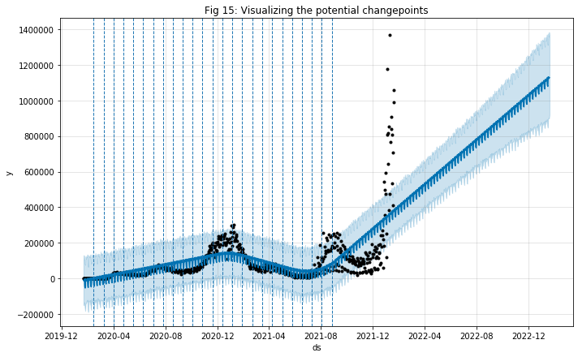

```python
#visualizing the potential changepoints
figure = model.plot(forecast)
for changepoint in model.changepoints:
    plt.axvline(changepoint,ls='--', lw=1)
    plt.title('Fig 15: Visualizing the potential changepoints')
```

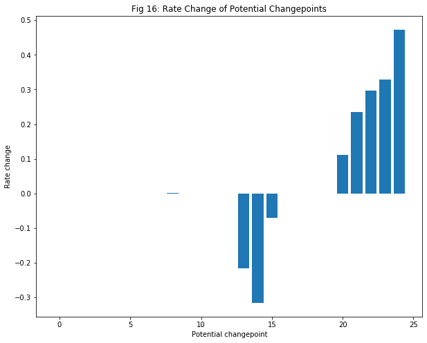

```python
# visualizing the rate change of all potential changepoints
deltas = model.params['delta'].mean(0)
fig = plt.figure(figsize=(10,8))
plt.bar(range(len(deltas)),deltas)
plt.ylabel('Rate change')
plt.xlabel('Potential changepoint')
plt.title('Fig 16: Rate Change of Potential Changepoints')
plt.show()
```

We can see that the last 5 changepoints have the most significant rate changes, and hence are contributing most to the trend. Apart from these, changepoints 13,14 and 15 are also contributing to the trend.

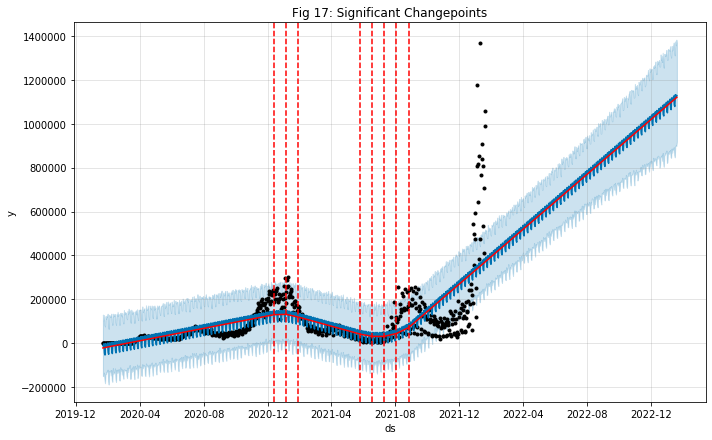

```python
#visualizing the significant changepoints
from fbprophet.plot import add_changepoints_to_plot
fig = model.plot(forecast)
a = add_changepoints_to_plot(fig.gca(), model, forecast)
plt.title('Fig 17: Significant Changepoints')
plt.show()
```

As highlighted above, total 8 changepoints are contributing significantly towards the trend of the time series

```
INFO:fbprophet:Disabling yearly seasonality. Run prophet with yearly_seasonality=True to override this.
INFO:fbprophet:Disabling daily seasonality. Run prophet with daily_seasonality=True to override this.
```

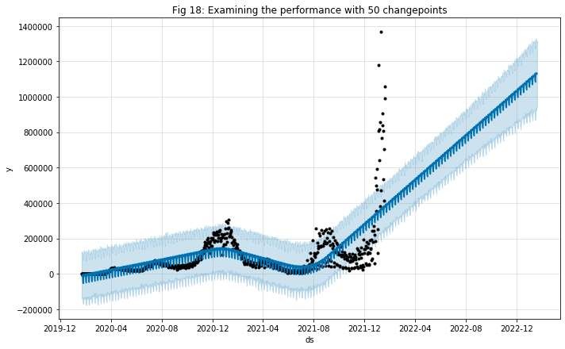

```python
#examining performance with 50 changepoints
model = Prophet(n_changepoints=50)
forecast = model.fit(dfb).predict(future)
fig = model.plot(forecast)
plt.title('Fig 18: Examining the performance with 50 changepoints')
```

```python
# in sample RMSE
yhat = forecast[:-365]['yhat']
y = dfb['y']
RMSE = np.sqrt((np.power((yhat - y),2)).mean())
RMSE
```

```
101788.71909567587
```

In sample RMSE of the model with 50 changepoints is higher than the model with 25 changepoints. We would go ahead with 25 changepoints.

### Seasonality Assessment

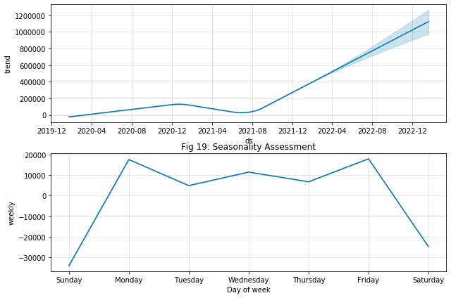

```python
model.plot_components(forecast)
plt.title('Fig 19: Seasonality Assessment')
plt.show()
```

As concluded above as well, the time series follows a weekly seasonality. We need to examine further to understand whether it is additive seasonality or multiplicative seasonality.

```
INFO:fbprophet:Disabling yearly seasonality. Run prophet with yearly_seasonality=True to override this.
INFO:fbprophet:Disabling daily seasonality. Run prophet with daily_seasonality=True to override this.
```

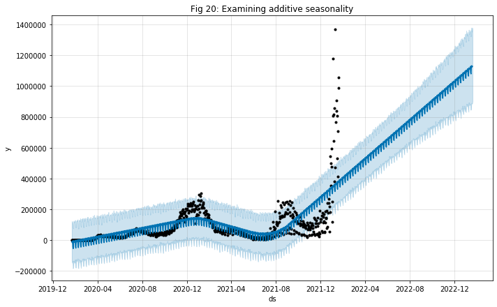

```python
#examining additive seasonality
model = Prophet(seasonality_mode='additive')
forecast = model.fit(dfb).predict(future)
fig = model.plot(forecast)
plt.title('Fig 20: Examining additive seasonality')
plt.show()
```

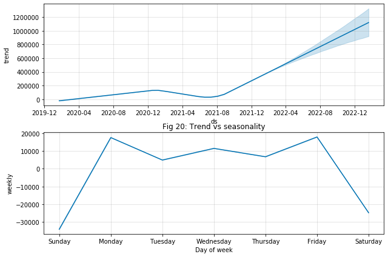

```python
model.plot_components(forecast)
plt.title('Fig 20: Trend vs seasonality')
plt.show()
```

From the above decomposition chart, we can observe that the trend is driving the forecasted values more as compared to the seasonality.

```python
# calculating in sample RMSE
yhat = forecast[:-365]['yhat']
y = dfb['y']
RMSE = np.sqrt((np.power((yhat - y),2)).mean())
RMSE
```

```
101675.54395801513
```

```
INFO:fbprophet:Disabling yearly seasonality. Run prophet with yearly_seasonality=True to override this.
INFO:fbprophet:Disabling daily seasonality. Run prophet with daily_seasonality=True to override this.
```

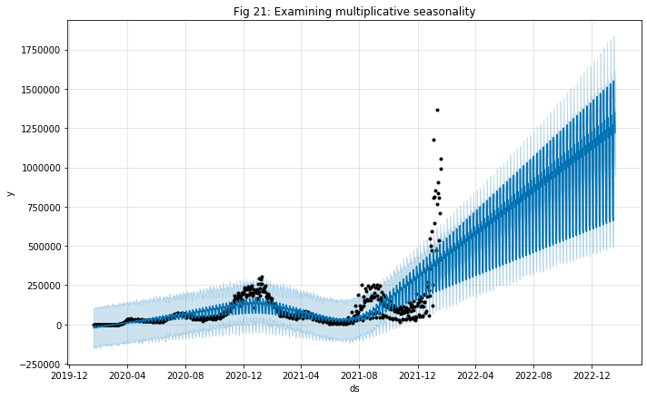

```python
#examining multiplicative seasonality
model = Prophet(seasonality_mode='multiplicative')
forecast = model.fit(dfb).predict(future)
fig = model.plot(forecast)
plt.title('Fig 21: Examining multiplicative seasonality')
plt.show()
```

We can see that the variance of the values forecasted by mutliplicative seasonality keeps on increasing with time

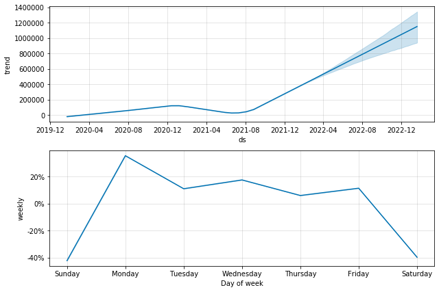

```python
model.plot_components(forecast)
plt.show()
```

```python
# in sample RMSE
yhat = forecast[:-365]['yhat']
y = dfb['y']
RMSE = np.sqrt((np.power((yhat - y),2)).mean())
RMSE
```

```
97548.75887466707
```

The in sample RMSE of multiplicative seasonality is slightly lower than the additive seasonality. However, difference in performance is not significant enough to prefer multiplicative seasonality over additive seasonality as the model will become more difficult to interpret. Hence, we would go ahead with additive seasonality.

### Assessment and inclusion of holidays

```python
import holidays
holidays = pd.DataFrame(holidays.UnitedStates(years=[2020,2021,2022,2023]).items())
holidays.columns = ['ds','holiday']
```

```python
model = Prophet(holidays=holidays)
model.add_country_holidays(country_name='US')
model.fit(dfb)
```

```
INFO:fbprophet:Disabling yearly seasonality. Run prophet with yearly_seasonality=True to override this.
INFO:fbprophet:Disabling daily seasonality. Run prophet with daily_seasonality=True to override this.
```

```
<fbprophet.forecaster.Prophet at 0x7fe1075dfb10>
```

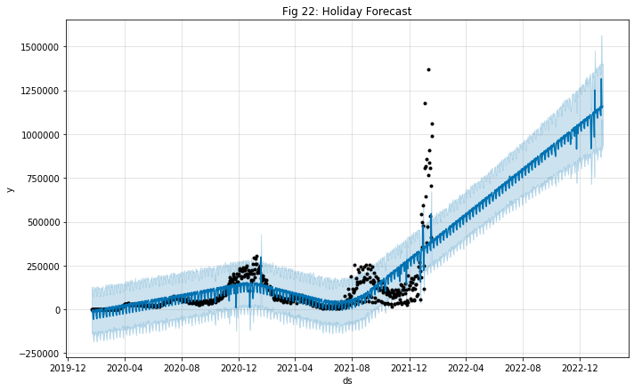

```python
forecast = model.predict(future)
model.plot(forecast)
plt.title('Fig 22: Holiday Forecast')
plt.show()
```

```python
forecast[:-365].tail()
```

|  | ds | trend | yhat_lower | yhat_upper | trend_lower | trend_upper | Christmas Day | Christmas Day_lower | Christmas Day_upper | Christmas Day (Observed) | ... | holidays | holidays_lower | holidays_upper | weekly | weekly_lower | weekly_upper | multiplicative_terms | multiplicative_terms_lower | multiplicative_terms_upper | yhat |
| --- | --- | --- | --- | --- | --- | --- | --- | --- | --- | --- | --- | --- | --- | --- | --- | --- | --- | --- | --- | --- | --- |
| 724 | 2022-01-15 | 368809.670113 | 211450.259535 | 471601.697556 | 368809.670113 | 368809.670113 | 0.0 | 0.0 | 0.0 | 0.0 | ... | 0.000000 | 0.000000 | 0.000000 | -23970.425537 | -23970.425537 | -23970.425537 | 0.0 | 0.0 | 0.0 | 344839.244575 |
| 725 | 2022-01-16 | 370924.994570 | 212802.012951 | 453382.716798 | 370924.994570 | 370924.994570 | 0.0 | 0.0 | 0.0 | 0.0 | ... | 0.000000 | 0.000000 | 0.000000 | -35562.944531 | -35562.944531 | -35562.944531 | 0.0 | 0.0 | 0.0 | 335362.050038 |
| 726 | 2022-01-17 | 373040.319027 | 425201.370278 | 673159.360473 | 373040.319027 | 373040.319027 | 0.0 | 0.0 | 0.0 | 0.0 | ... | 155496.220867 | 155496.220867 | 155496.220867 | 17556.704523 | 17556.704523 | 17556.704523 | 0.0 | 0.0 | 0.0 | 546093.244417 |
| 727 | 2022-01-18 | 375155.643484 | 254138.481431 | 506514.465324 | 375155.643484 | 375155.643484 | 0.0 | 0.0 | 0.0 | 0.0 | ... | 0.000000 | 0.000000 | 0.000000 | 3441.571713 | 3441.571713 | 3441.571713 | 0.0 | 0.0 | 0.0 | 378597.215197 |
| 728 | 2022-01-19 | 377270.967941 | 258833.971640 | 516729.874154 | 377270.967941 | 377270.967941 | 0.0 | 0.0 | 0.0 | 0.0 | ... | 0.000000 | 0.000000 | 0.000000 | 10833.622787 | 10833.622787 | 10833.622787 | 0.0 | 0.0 | 0.0 | 388104.590728 |

5 rows × 61 columns

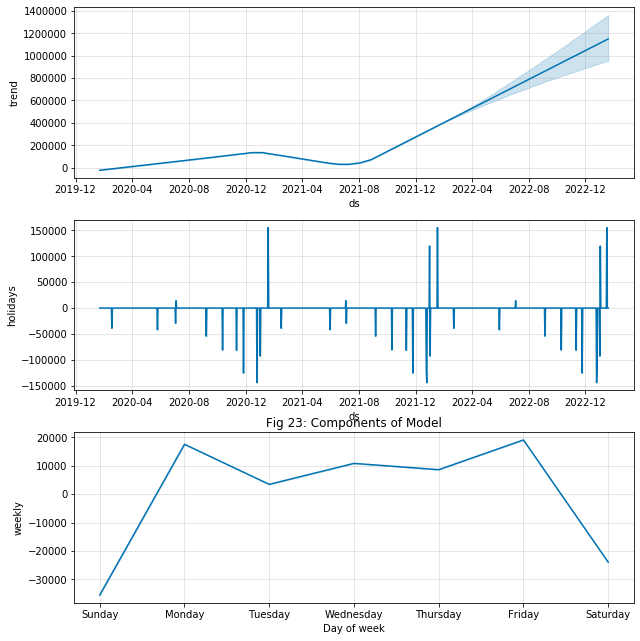

```python
model.plot_components(forecast)
plt.title('Fig 23: Components of Model')
plt.show()
```

On observing the holiday component, we can conclude that most of the holidays have a negative impact on the number of new cases. A few holidays (yearly twice) have a positive impact on the number of new cases.

```python
# in sample RMSE
yhat = forecast[:-365]['yhat']
y = dfb['y']
RMSE = np.sqrt((np.power((yhat - y),2)).mean())
RMSE
```

```
99977.73634238409
```

The in sample RMSE of the model after including holidays has improved.

### Cross Validation

Prophet includes functionality for time series cross validation to measure forecast error using historical data. This is done by selecting cutoff points in the history, and for each of them fitting the model using data only up to that cutoff point. We can then compare the forecasted values to the actual values.

```python
from fbprophet.diagnostics import cross_validation
df_cv = cross_validation(model, initial = '360 days', period='30 days', horizon = '30 days')
df_cv.head()
```

```
INFO:fbprophet:Making 12 forecasts with cutoffs between 2021-01-24 00:00:00 and 2021-12-20 00:00:00
```

|  | ds | yhat | yhat_lower | yhat_upper | y | cutoff |
| --- | --- | --- | --- | --- | --- | --- |
| 0 | 2021-01-25 | 251793.421376 | 225778.587215 | 277663.591673 | 142110 | 2021-01-24 |
| 1 | 2021-01-26 | 258315.169535 | 230487.877976 | 284570.640439 | 144773 | 2021-01-24 |
| 2 | 2021-01-27 | 262407.279751 | 233823.351504 | 289071.154455 | 155128 | 2021-01-24 |
| 3 | 2021-01-28 | 268521.506481 | 240780.523506 | 295483.315218 | 167434 | 2021-01-24 |
| 4 | 2021-01-29 | 273232.957695 | 245984.104198 | 299181.486928 | 165838 | 2021-01-24 |

The model has fit data for 12 cut off points for an initial training period of 360 days, period of 30 days and horizon of 30 days.

```python
#examining performance metrics of cross validation models
from fbprophet.diagnostics import performance_metrics
df_p = performance_metrics(df_cv)
df_p.head()
```

|  | horizon | mse | rmse | mae | mape | coverage |
| --- | --- | --- | --- | --- | --- | --- |
| 0 | 3 days | 4.745372e+09 | 68886.662224 | 53813.985416 | 0.744855 | 0.361111 |
| 1 | 4 days | 4.561433e+09 | 67538.378812 | 54659.086557 | 0.803064 | 0.333333 |
| 2 | 5 days | 4.921252e+09 | 70151.637158 | 56821.317535 | 0.846424 | 0.305556 |
| 3 | 6 days | 4.318475e+09 | 65715.107205 | 53285.020724 | 0.767983 | 0.333333 |
| 4 | 7 days | 9.581163e+09 | 97883.417710 | 65621.094223 | 0.828694 | 0.333333 |

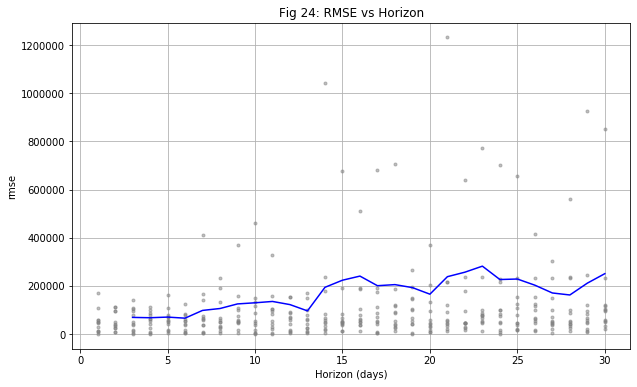

```python
from fbprophet.plot import plot_cross_validation_metric
fig = plot_cross_validation_metric(df_cv, metric='rmse')
plt.title('Fig 24: RMSE vs Horizon')
plt.show()
```

As seen from the above chart, the RMSE of the model increases with increase in horizon which is expected because time series models are better at predicting near point in the future as compared to predicted a point which is far away into the future.

## ARIMA vs Facebook Prophet

```python
# splitting time series into train and test
train = df[:600]
test = df[600:]
```

We have split our data into training and testing dataset with first 600 days in train and the next 129 days in test.

## Fitting best ARIMA Model

The best ARIMA model obtained was ARIMA(5,2,2). We will fit that

```python
# taking log of train data
ln_train = np.log(train)
ln_df.head()
```

| date | new_cases |
| --- | --- |
| 2020-01-22 | 0.000000 |
| 2020-01-23 | 0.000000 |
| 2020-01-24 | 0.000000 |
| 2020-01-25 | 0.000000 |
| 2020-01-26 | 1.098612 |

```python
# fitting the best model (5,2,2)
arima = ARIMA(ln_train['new_cases'], order=(5,2,2))
arima_fit = arima.fit()
print(arima_fit.summary())
```

```
                             ARIMA Model Results
==============================================================================
Dep. Variable:           D2.new_cases   No. Observations:                  598
Model:                 ARIMA(5, 2, 2)   Log Likelihood                -192.340
Method:                       css-mle   S.D. of innovations              0.332
Date:                Sat, 26 Feb 2022   AIC                            402.680
Time:                        14:45:54   BIC                            442.222
Sample:                    01-24-2020   HQIC                           418.075
                         - 09-12-2021
======================================================================================
                         coef    std err          z      P>|z|      [0.025      0.975]
--------------------------------------------------------------------------------------
const                 -0.0002      0.003     -0.083      0.934      -0.005       0.005
ar.L1.D2.new_cases    -0.0984      0.034     -2.855      0.004      -0.166      -0.031
ar.L2.D2.new_cases    -0.5372      0.028    -18.904      0.000      -0.593      -0.481
ar.L3.D2.new_cases    -0.4545      0.030    -14.929      0.000      -0.514      -0.395
ar.L4.D2.new_cases    -0.4342      0.028    -15.527      0.000      -0.489      -0.379
ar.L5.D2.new_cases    -0.6094      0.034    -17.901      0.000      -0.676      -0.543
ma.L1.D2.new_cases    -1.2586      0.020    -62.049      0.000      -1.298      -1.219
ma.L2.D2.new_cases     0.8779      0.023     37.769      0.000       0.832       0.923
                                    Roots
=============================================================================
                  Real          Imaginary           Modulus         Frequency
-----------------------------------------------------------------------------
AR.1            0.6233           -0.7857j            1.0030           -0.1433
AR.2            0.6233           +0.7857j            1.0030            0.1433
AR.3           -0.3517           -1.0841j            1.1398           -0.2999
AR.4           -0.3517           +1.0841j            1.1398            0.2999
AR.5           -1.2558           -0.0000j            1.2558           -0.5000
MA.1            0.7169           -0.7907j            1.0673           -0.1328
MA.2            0.7169           +0.7907j            1.0673            0.1328
-----------------------------------------------------------------------------
```

```python
# generating foreacasts for the next 129 days
n=129
forecast,err,ci = arima_fit.forecast(steps=n)
arima_forecast = pd.DataFrame({'forecast':forecast},index=pd.date_range(start='2021/09/13', periods=n))
```

```python
#taking inverse of log to get back to original scale
arima_forecast['forecast'] = np.exp(arima_forecast['forecast'])
arima_forecast.head()
```

|  | forecast |
| --- | --- |
| 2021-09-13 | 117195.725191 |
| 2021-09-14 | 187432.969032 |
| 2021-09-15 | 149023.275235 |
| 2021-09-16 | 160264.537137 |
| 2021-09-17 | 110691.181373 |

```python
# Calculating RMSE
yhat = arima_forecast['forecast']
y = test['new_cases']
RMSE = np.sqrt((np.power((yhat - y),2)).mean())
RMSE
```

```
333316.27267367474
```

```python
#calculating MAE
MAE = np.abs((yhat - y)).mean()
MAE
```

```
195559.72845381688
```

```python
#calculating MAPE
MAPE = np.abs((yhat - y)/y).mean()
MAPE
```

```
0.8258449101795012
```

### Fitting best FB Prophet Model

The best FB Prophet model obtained was the model with additive weekly seasonality which included holiday impact as well.

```python
fb_train = train.reset_index()
fb_train.columns = ['ds','y']
```

```python
# fitting the model
fb_model = Prophet(holidays=holidays)
fb_model.add_country_holidays(country_name='US')
fb_model.fit(fb_train)
```

```
INFO:fbprophet:Disabling yearly seasonality. Run prophet with yearly_seasonality=True to override this.
INFO:fbprophet:Disabling daily seasonality. Run prophet with daily_seasonality=True to override this.
```

```
<fbprophet.forecaster.Prophet at 0x7fe106993e90>
```

```python
# Create Future dates and forecasting
future = model.make_future_dataframe(periods=0)

# Predict Prices
fb_forecast = model.predict(future)
fb_forecast[['ds', 'yhat', 'yhat_lower', 'yhat_upper']].tail()
```

|  | ds | yhat | yhat_lower | yhat_upper |
| --- | --- | --- | --- | --- |
| 724 | 2022-01-15 | 344839.244575 | 213111.438344 | 472535.407245 |
| 725 | 2022-01-16 | 335362.050038 | 211659.812966 | 460808.453471 |
| 726 | 2022-01-17 | 546093.244417 | 417138.352464 | 676943.908865 |
| 727 | 2022-01-18 | 378597.215197 | 253076.357535 | 499979.706989 |
| 728 | 2022-01-19 | 388104.590728 | 267659.658037 | 532478.119715 |

```python
# Calculating RMSE
yhat = fb_forecast['yhat'].values[600:]
y = test['new_cases']
RMSE = np.sqrt((np.power((yhat - y),2)).mean())
RMSE
```

```
214758.46748377391
```

```python
#calculating MAE
MAE = np.abs((yhat - y)).mean()
MAE
```

```
153661.0356472884
```

```python
#calculating MAPE
MAPE = np.abs((yhat - y)/y).mean()
MAPE
```

```
1.437798377565072
```